# ETC5521 Tutorial 8

Note also, that imputed values for `bedroom2`, `bathroom` and `car` have been rounded to integer. The regression model will impute these with decimal places, which is not realistic in the later analysis. This is one place, where I iterated in the handling os missings after noticing that bedrooms and bathrooms looked odd.

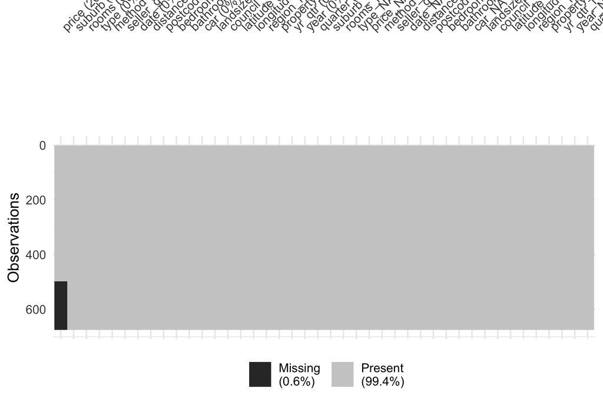

```r
# Conduct imputation, carefully!
mel_houses_imputed <- mel_houses_na |>
  nabular() |>
  as.data.frame() |>
  # bedroom2
  impute_lm(bedroom2 ~ type + quarter + year +
              latitude + longitude +
              postcode + distance) |>
  mutate(bedroom2 = round(bedroom2, 0)) |>
  # bathroom
  impute_lm(bathroom ~ type + quarter + year +
              latitude + longitude +
              postcode + distance) |>
  mutate(bathroom = round(bathroom, 0)) |>
  # car
  impute_lm(car ~ type + quarter + year +
              bedroom2 + bathroom + latitude +
              longitude + postcode + distance) |>
  mutate(car = round(car, 0)) |>
  # landsize
  impute_lm(landsize ~ type + quarter + year +
              bedroom2 + bathroom +
              latitude + longitude +
              postcode + distance)

# check again
vis_miss(mel_houses_imputed, cluster = TRUE,
         sort_miss = TRUE)
```

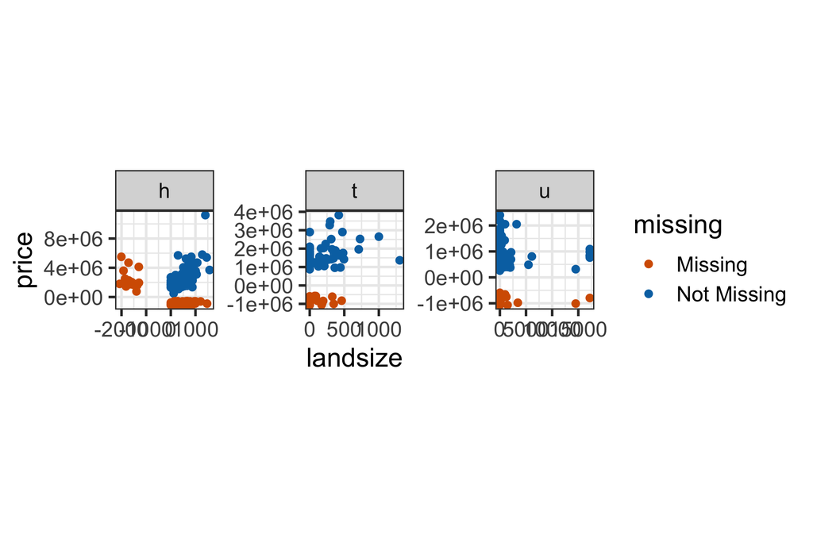

```r
ggplot(mel_houses_na, aes(x=landsize, y=price)) +
  geom_miss_point() +
  facet_wrap(~type, ncol=3, scales="free") +
  theme(aspect.ratio = 1)
```

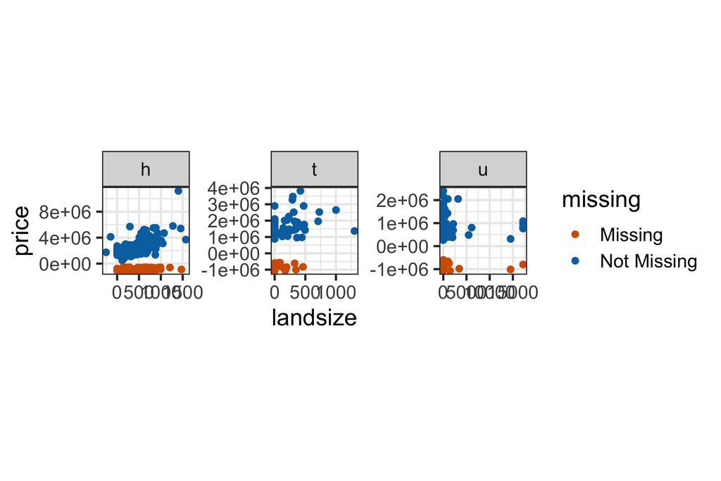

```r
ggplot(mel_houses_imputed, aes(x=landsize, y=price)) +
  geom_miss_point() +
  facet_wrap(~type, ncol=3, scales="free") +
  theme(aspect.ratio = 1)
```

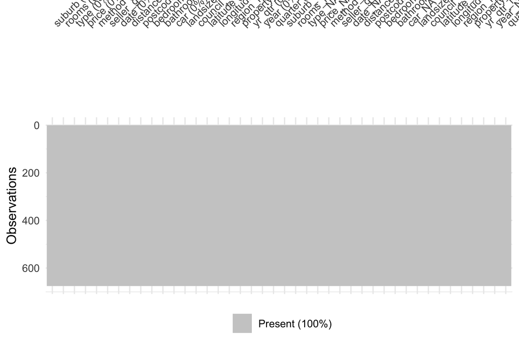

```r
# Also check bedroom2, bathroom and car

# price
mel_houses_imputed <- mel_houses_imputed |>
  impute_lm(price ~ type + quarter + year + landsize +
              bedroom2 + bathroom + latitude +
              longitude + postcode + distance)
# check again
vis_miss(mel_houses_imputed, cluster = TRUE, sort_miss = TRUE)
```

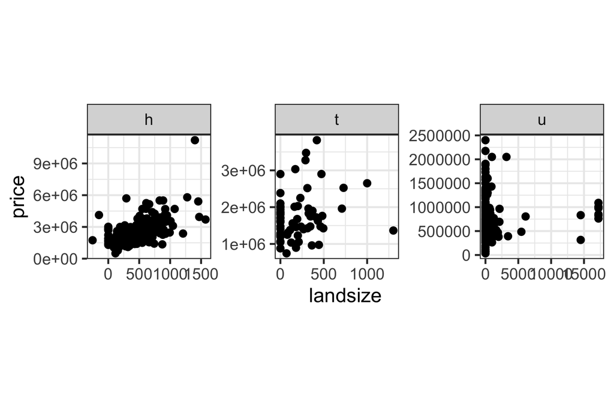

```r
ggplot(mel_houses_imputed, aes(x=landsize, y=price)) +
  geom_point() +
  facet_wrap(~type, ncol=3, scales="free") +
  theme(aspect.ratio = 1)
```

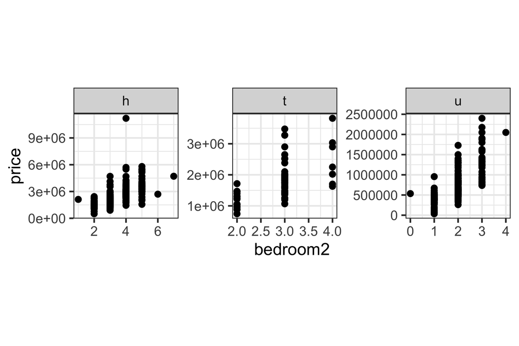

```r
ggplot(mel_houses_imputed, aes(x=bedroom2, y=price)) +
  geom_point() +
  facet_wrap(~type, ncol=3, scales="free") +
  theme(aspect.ratio = 1)
```

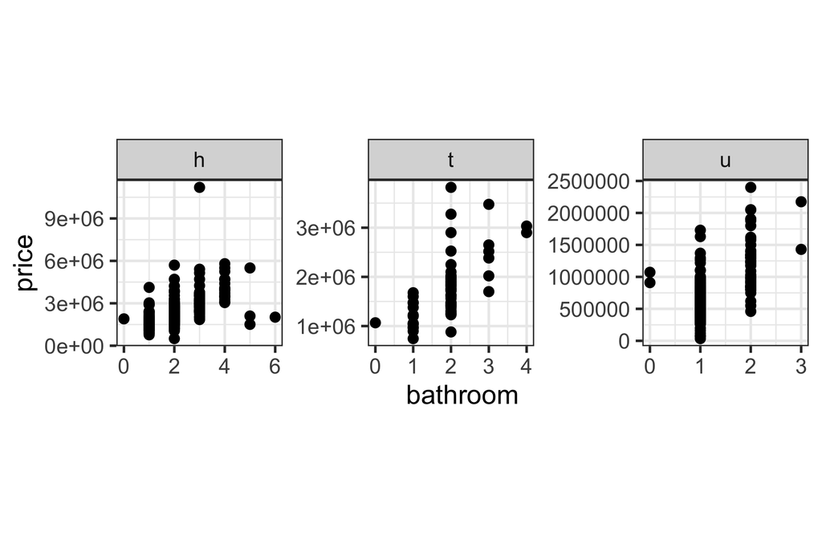

```r
ggplot(mel_houses_imputed, aes(x=bathroom, y=price)) +
  geom_point() +
  facet_wrap(~type, ncol=3, scales="free") +
  theme(aspect.ratio = 1)
```

```r
# Now add label
mel_houses_imputed <- mel_houses_imputed |>
  add_label_shadow()
# Note: method not used because it causes problems with missing factor levels. Ideally it is included.
```

One more check of resulting data.

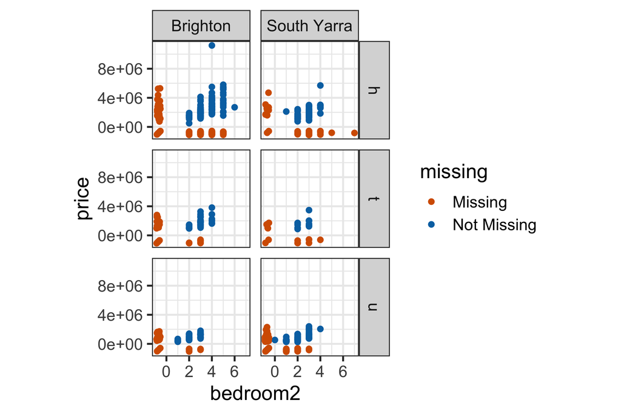

```r
ggplot(mel_houses, aes(x=bedroom2, y=price)) +
         geom_miss_point() +
         facet_grid(type~suburb)
```

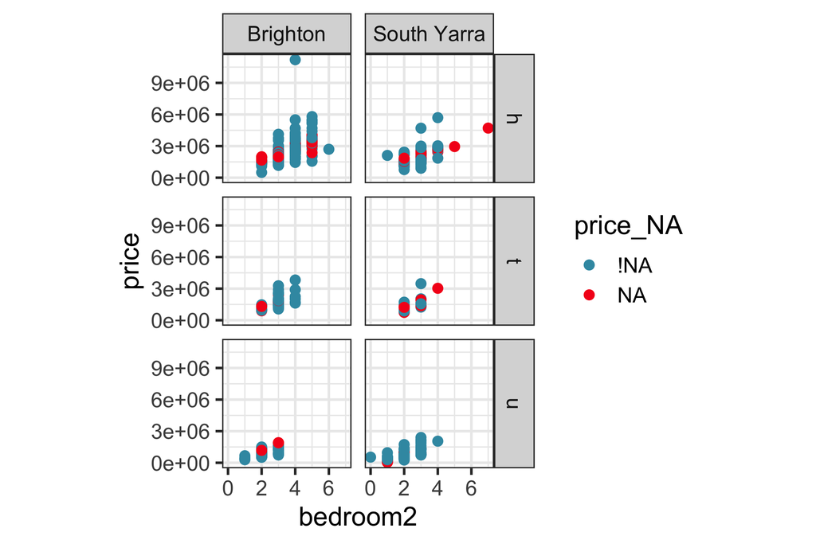

```r
ggplot(mel_houses_imputed, aes(x=bedroom2, y=price, colour=price_NA)) +
         geom_point() +
         facet_grid(type~suburb) +
  scale_colour_discrete_divergingx(palette="Zissou 1")
```

Ok, quite confident now that we have a reasonable set of data to work with. There are some odd values in the data still that will need handling at some point, like *negative* `landsize`. But for now these can be part of the analysis, as is.

Having the additional variables `_NA` will allow identifying observations that have been imputed as we work through the analysis.

4. Make a scatterplot matrix of price, rooms, bedroom2, bathroom, landsize, latitude and longitude, suburb. The order of variables can affect the readability. I advise that the plot will be easier to read if you order the variables a little, at least put price first. Think about what associations can be seen?

**SolutionSolution**

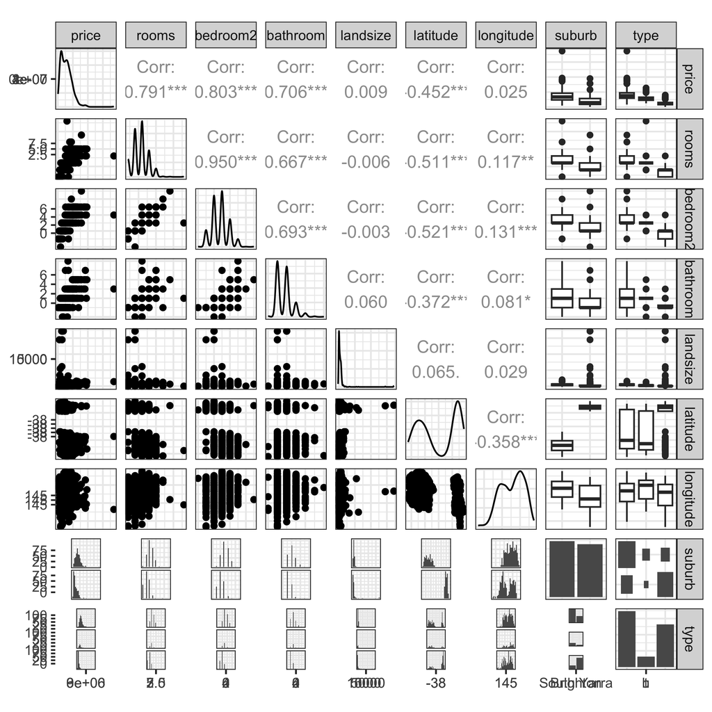

```r
ggpairs(mel_houses_imputed,
        columns=c(4,2,10,11,13,15,16,1,3))
```

- Some continuous variables are discrete. We can still examine the associations. It could be useful to use a jittered scatterplot, but that would require making a special plot function to use in the ggpairs function.
- There is positive linear association between price, rooms, bedroom2, bathroom, which indicates the bigger the house the higher the price
- From the boxplots: houses in Brighton tend to be higher priced and bigger than South Yarra, and houses tend to be worth more than townhouses and units.
- There are lots of outliers.

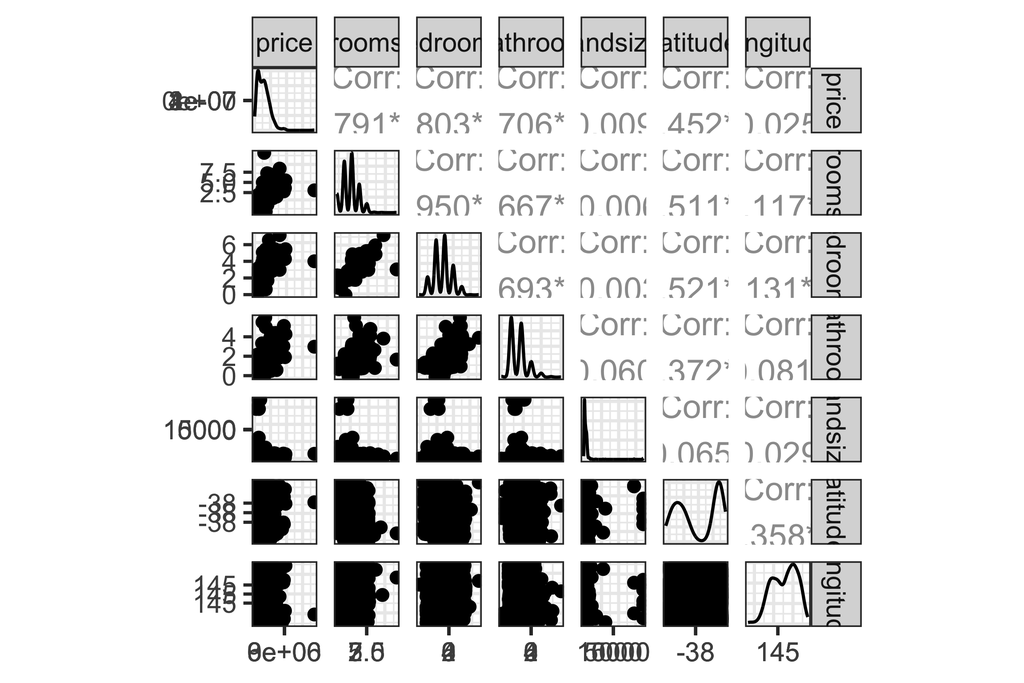

```r
# To add jitter
ggpairs(mel_houses_imputed,
        columns=c(4,2,10,11,13,15,16),
        lower=list(continuous=wrap("points",
                  position=position_jitter(height=0.3, width=0.3))))
```

5. Here’s where we will start using interactive plots to explore the multivariate relationships. Subset the data to Brighton only. This will make the analysis easier. Make an interactive scatterplot matrix of price, rooms, bedroom2, bathroom and landsize, coloured by type of property. There are some high price properties. Select these cases, and determine what’s special about them – if anything.

**SolutionSolution**

```r
brighton <- mel_houses_imputed |>
  dplyr::filter(suburb=="Brighton")
highlight_key(brighton) |>
  ggpairs(aes(shape = price_NA, colour=type),
          columns = c(4,2,10,11,13),
                  upper=list(continuous="points")) |>
  ggplotly(900, 900) |>
  highlight("plotly_selected")
```

[interactive chart not shown]

```r
# To add jittering
# which makes it a little easier to see all points
# in the discrete variables
highlight_key(brighton) |>
  ggpairs(aes(shape = price_NA, colour=type),
          columns = c(4,2,10,11,13),
          lower=list(continuous=wrap("points",
                  position=position_jitter(height=0.3, width=0.3))),
          upper=list(continuous=wrap("points",
                  position=position_jitter(height=0.3, width=0.3)))) |>
  ggplotly(900, 900) |>
  highlight("plotly_selected")
```

[interactive chart not shown]

- There is one very high price, which is a modest size of 4 bedrooms and 3 bathrooms.
- There is one property with an extraordinarily large number of rooms, but this is an imputed value for price. Something may have gone wrong with the imputation, because it has a low price despite being a big property. Despite the large number of rooms it only has 3 bedrooms and 2 bathrooms.
6. The realtors mantra is location, location, location! Next check the location of properties relative to price and size, using two linked plots. One should have the longitude and latitude, and the other price by rooms. Ideally, you can make a map underneath the spatial coordinates, to better put these in context.

**SolutionSolution**

The `ozmaps` package has quick maps of Australia that can be used. The code below checks that the map can be made.

```r
# Check location
library(sf)
library(ozmaps)
library(ggthemes)
library(crosstalk)
lga_sf <- ozmap_data("abs_lga")
brighton_map <- lga_sf |>
  filter(NAME %in% c("Bayside (C)",
                     "Glen Eira (C)",
                     "Stonnington (C)",
                     "Port Phillip (C)"))
basic_map <- ggplot(brighton_map) + geom_sf() +
  geom_point(data=brighton,
             aes(x=longitude, y=latitude,
                 colour=type, shape=price_NA)) +
  theme_map() +
  theme(legend.position = "none")
```

This code can be used to make the interactive linked plots.

```r
# Now make interactive linked plots
shared_brighton <- SharedData$new(brighton)

map <- ggplot(brighton_map) +
  geom_sf() +
  geom_point(data=shared_brighton,
             aes(x=longitude, y=latitude,
                 colour=type, shape=price_NA)) +
  theme_map() +
  theme(legend.position = "none")

sp <- ggplot(shared_brighton,
             aes(x=rooms, y=price,
                 colour=type,
                 shape=price_NA)) +
  geom_point() +
  theme(legend.position="none")

mapi <- ggplotly(map) |>
  highlight(on = "plotly_selected",
              off = "plotly_deselect")
spi <- ggplotly(sp) |>
  highlight(on = "plotly_selected",
              off = "plotly_deselect")

bscols(
  widths = c(5, 5),
  mapi,
  spi
 )
```

[interactive chart not shown]

- The high priced house is right against the bay.
- The property with the large number of rooms is also close to the bay.
- Otherwise, if you select the properties near the bay, they don’t seem to be especially higher in price.

### Exercise 2: Challenges

For each of the data sets, `c1`, …, `c7` from the `mulgar` package, use the grand tour to view and try to identify structure (outliers, clusters, non-linear relationships).

**SolutionSolution**

```r
library(mulgar)
animate_xy(c1)
# four small clusters, two big clusters
# linear dependence
animate_xy(c2)
# Six spherical clusters
animate_xy(c3)
# tetrahedron with lots of smaller triangles,
# barriers, linear dependence
animate_xy(c4)
# Four linear connected pieces
animate_xy(c5)
# Spiral in lower dimensional space
# Non-linear and linear dependence
animate_xy(c6)
# Two curved clusters
animate_xy(c7)
# spherical cluster, curve cluster and a lot of noise points
```

## 👌 Finishing up

Make sure you say thanks and good-bye to your tutor. This is a time to also report what you enjoyed and what you found difficult.